# Biodiversity across a salinity gradient

Mar Schmidt

April 13, 2026

# Goals

Run an analysis on the within-sample biodiversity of the samples in our project.

1. Calculate the Hill Numbers of the samples using the iNEXT package.
2. Plot and evaluate the interpolated and extrapolated rarefaction curves from iNEXT.
3. Analyze the Hill numbers as it relates to stations and salinity (in PSU).
4. Test and then answer the scientific question at hand! (Remember, we’re doing biology!)
1. We will need the `preprocessed_physeq` that we created in `analysis/03_PreProcessing.Rmd`, which has the chloroplasts, mitochondria, and any controls removed.

## Outputs

*This is an exciting analysis!!! We finally get to answer one of our scientific questions!*

1. Calculated biodiversity measures (Hill numbers) across every sample.
2. Figures to include in our scientific paper that visualize the data as it relates to the scientific question.
3. Statistical tests conveying the measured and quantified changes and patterns in biodiversity.

# Scientific Question

## Question & Hypotheses

How is microbial biodiversity modified across a salinity gradient?

- *Null Hypothesis:* Microbial biodiversity (*e.g.* richness) does not vary along a salinity gradient.
- *Alternative Hypothesis:* Microbial biodiversity (*e.g.* richness) will increase as salt concentration lowers. There is an inverse relationship between richness and salinity.

## Field site background

To answer this scientific question, I performed a study in the Gulf of Mexico to take advantage of a natural salinity gradient in an estuarine ecosystem, known as the Mission-Aransas Estuary.

### Mission-Aransas Estuary

*Remember what we were doing before we got all distracted with the details of ASVs, pre-processing, and phylogenetics?* We actually conducted a study to evaluate the role that salinity plays in shaping Estuarine Microbial Communities in the Gulf of Mexico at the long-term SWMP stations at the [Mission-Aransas National Estuarine Research Reserve (NERR)](https://marinescience.utexas.edu/research/mission-aransas-reserve#:~:text=The%20Mission%2DAransas%20National%20Estuarine%20Research%20Reserve%20is%20a%20federal,of%20Texas%20Marine%20Science%20Institute).

**What’s a NERR?** The [National Oceanic and Atmospheric Administration (NOAA) maintains 30 estuarine research reserves across the country](https://coast.noaa.gov/nerrs/). There are 5 in the Gulf of Mexico, two (soon to be three!) in the Great Lakes, among others across the United States!

*Let’s get to calculating Biodiversity!*

# Set up the Environment

## Timing of this script

```r
# What time did we start running this script?
start_time <- Sys.time()
```

## Set the seed

```r
set.seed(238428)
```

## Load Packages & Colors

```r
# load packages
pacman::p_load(tidyverse, devtools, patchwork, iNEXT, phyloseq,
               # packages for stats
               ggpubr, rstatix, install = FALSE)

# Load in colors for plotting
source("code/colors_and_shapes.R")
```

## Load in Data

```r
load("data/Lecture/03_PreProcessing_Lecture/preprocessed_phyloseq.RData")

# take a look at it!
preprocessed_physeq
```

```
## phyloseq-class experiment-level object
## otu_table()   OTU Table:         [ 2677 taxa and 89 samples ]
## sample_data() Sample Data:       [ 89 samples by 43 sample variables ]
## tax_table()   Taxonomy Table:    [ 2677 taxa by 9 taxonomic ranks ]
```

```r
# Intuition check on seq depth
min(sample_sums(preprocessed_physeq))
```

```
## [1] 1844
```

```r
# Make a metadata dataframe
metadata_df <-
  preprocessed_physeq %>%
  sample_data() %>%
  data.frame()

# view of it
glimpse(metadata_df)
```

```
## Rows: 89
## Columns: 43
## $ names               <chr> "20210602-MA-ABB1F", "20210602-MA-ABB1P", "2021060…
## $ year                <chr> "2021", "2021", "2021", "2021", "2021", "2021", "2…
## $ day                 <chr> "02", "02", "02", "02", "02", "02", "02", "02", "0…
## $ project             <chr> "MA", "MA", "MA", "MA", "MA", "MA", "MA", "MA", "M…
## $ station             <ord> Aransas Bay, Aransas Bay, Aransas Bay, Aransas Bay…
## $ depth               <dbl> 2.5, 2.5, 2.5, 0.0, 0.0, 0.0, 2.0, 2.0, 2.0, 0.0, …
## $ replicate           <chr> "1", "1", "1", "1", "1", "1", "1", "1", "1", "1", …
## $ fraction            <fct> Free, Particle, Whole, Free, Particle, Whole, Free…
## $ date                <ord> 6/2/21, 6/2/21, 6/2/21, 6/2/21, 6/2/21, 6/2/21, 6/…
## $ month               <chr> "June", "June", "June", "June", "June", "June", "J…
## $ vol_filtered_mL     <int> 360, 360, 360, 300, 300, 300, 183, 183, 285, 146, …
## $ DNA_conc1a_nguL     <dbl> 25.90, 2.91, 65.30, 39.70, 10.40, 47.40, 32.50, 1.…
## $ total_uL_DNA        <dbl> 44.61, 34.00, 43.36, 44.94, 42.54, 45.11, 44.89, 3…
```

[output cut: 30 more lines]

# Biodiversity Hill Numbers with iNEXT

## Hill Number Equation

Next, we will calculate the biodiversity with the [iNEXT package](https://besjournals.onlinelibrary.wiley.com/doi/full/10.1111/2041-210X.12613) package. iNEXT focuses on three measures of biodiversity via the Hill numbers. Hill numbers have the order q:

$${}^qD = \left( \sum_{i=1}^{S} p_i^q \right)^{1/(1 - q)}, \quad q \geq 0,
\quad q \neq 1.$$

But when *q = 1*, then the equation is:

$${}^1D = \lim_{q \to 1} {}^qD = \exp\left( - \sum_{i=1}^{S} p_i \log p_i
\right) = \exp(H_{sh}).$$

**Where:**

- ${}^qD$ is the *Hill number* or *diversity of order $q$*, a measure of species diversity.
- $q$ is the *order of diversity*, which determines how sensitive the measure is to species relative abundances:
  - $q = 0$: all species are weighted equally or **species richness**,
  - $q = 1$: corresponds to the exponential of **Shannon entropy**,
  - $q = 2$: corresponds to the **inverse of Simpson’s index**.
- $S$ is the *total number of species* in the community.
- $p_i$ is the *relative abundance* of species $i$, i.e., the proportion of individuals in the community belonging to species $i$.

## Microbial Example 🦠

Imagine you’re studying the microbial diversity in three sourdough starters from three different bakers: A, B, and C. Each one contains a mix of **ASVs**. *But how diverse are they, really?* Here,’s a great application of the **Hill numbers** to find out, varying the value of $q$.

### When $q = 0$: Counting *All* ASVs Equally

> *Species Richness* → ${}^0D$

Here, we ignore how common or rare each ASV is. Every ASV counts equally — even ones that appear just once. For example, this is like walking into a library and simply counting how many unique book titles are on the shelves—not how many copies of each exist, just the number of different titles. So, even if there’s only one copy of most books and 100 copies of one, they all count the same.

Here, in the context of microbial communities, we are pondering: **“How many different ASVs are present?”** We do not weight them by abundance/evenness in any way. Rather, we focus on a binary measures of 0s and 1s that represent presence (1) and absence (0).

- Baker A’s starter has 10 unique ASVs: ${}^0D_{\text{A}} = 10$
- Baker B’s has 7 unique ASVs: ${}^0D_{\text{B}} = 7$
- Baker C’s has 15 unique ASVs: ${}^0D_{\text{C}} = 15$

### When $q = 1$: Balancing Rarity and Commonness

> *Shannon Diversity* → ${}^1D$

Now we ask: **“How evenly are the ASVs distributed?”** Rare ASVs matter, but not as much as common ones. If we revisit the library analogy, now imagine you’re randomly picking books off the shelves to read. Some books have many more copies, so you’re more likely to pick those — but you still have a chance to encounter the rare ones. This measure reflects both richness and evenness — it tells you the effective number of “common” book titles based on their relative frequency. `q = 1` gives you a sense of how diverse your reading experience would be, considering popular vs. rare titles.

- Baker A’s 10 ASVs are 90% dominated by just one ASV: ${}^1D_{\text{A}} \approx 2$
- Baker B’s 7 ASVs are fairly even: ${}^1D_{\text{B}} \approx 6.8$
- Baker C’s 15 ASVs include 3 very dominant ones: ${}^1D_{\text{C}} \approx 5$

Even though Baker C and A have more ASVs in terms of richness in ${}^0D$, **Baker B** has the highest ${}^1D$ due to better balance between the abundances of its seven ASVs.

### When $q = 2$: Focus on the Most Abundant ASVs

> *Simpson-like Diversity* → ${}^2D$

Now we modify our question to wonder: **How many ASVs dominate each sample?** Here, rare ASVs hardly matter. For example, this is like walking into the library and only noticing the most abundant book titles, because they take up entire shelves. The rare titles are barely visible. Therefore, this measure emphasizes dominant species—those with many copies. `q = 2` tells us the effective number of dominant book titles, downplaying the presence of rare ones.

- Baker A’s starter is almost all one ASV of 10 total ASVs: ${}^2D_{\text{A}} \approx 1.2$
- Baker B’s 7 ASVs are balanced: ${}^2D_{\text{B}} \approx 6.5$
- Baker C’s has 3 dominant ASVs out of 15: ${}^2D_{\text{C}} \approx 3.5$

This tells us: **Baker B** has the most diverse community in terms of its *dominant* community members.

## Hill Number Summary Table

| Value of $q$ | Emphasis | Hill Number ${}^qD$ | Interpretation |
| --- | --- | --- | --- |
| $q = 0$ | Every ASV counts equally | ${}^0D$ | ASV richness — a simple count |
| $q = 1$ | Balance of common & rare | ${}^1D$ | Shannon Diversity — balanced view |
| $q = 2$ | Dominant ASVs matter most | ${}^2D$ | Simpson Diversity — focus on major players |

So, hopefully you can see that using Hill numbers like ${}^qD$ gives you a powerful, flexible way to describe microbial diversity — from just counting ASVs to understanding community structure. Next, we will calculate the biodiversity with the [iNEXT package](https://besjournals.onlinelibrary.wiley.com/doi/full/10.1111/2041-210X.12613) package. iNEXT focuses on three measures of biodiversity via the Hill numbers. For each Hill NUmber [iNEXT package](https://besjournals.onlinelibrary.wiley.com/doi/full/10.1111/2041-210X.12613) uses the observed abundance of species within a sample to compute diversity estimates and the associated 95% confidence intervals for the following two types of rarefaction and extrapolation (R/E):

1. **Sample-size-based (or size-based) R/E curves**: iNEXT computes diversity estimates for rarefied and extrapolated samples up to an appropriate size (2x the total number of individuals/sequences in that sample). This type of sampling curve plots the diversity estimates with respect to sample size.
2. **Coverage‐based R/E curves:** iNEXT computes diversity estimates for rarefied and extrapolated samples based on a standardized level of sample completeness (as measured by sample coverage) up to an appropriate coverage value. This type of sampling curve plots the diversity estimates with respect to sample coverage. **NOTE: Coverage is inapplicable to DADA2 datasets, as they lack singletons** (this is also why we can’t use Amy Willis’s breakaway approach).

*An important note:* We’ll be using the size_based output. Our lab has previously been suspicious of the Asymptotic Estimator. Therefore we will use the size_based approach here, with the caveat that we will very rigorously confirm that we’ve approached saturation for all of our samples!

> Warning! iNEXT takes a while to run, especially if your samples are deeply sequenced or if you have many samples! It is wise to calculate iNEXT early and then come back to the rest of the home work later on.

```r
# prepare the input data
# Species in rows and the samples in columns
iNEXT_input_df <-
  preprocessed_physeq %>%
  otu_table() %>%
  data.frame()

# Inpect
dim(iNEXT_input_df)
```

```
## [1] 2677   89
```

```r
iNEXT_input_df[1:5, 1:5]
```

```
##          X20210602.MA.ABB1F X20210602.MA.ABB1P X20210602.MA.ABB1W
## ASV_0001                599                415                881
## ASV_0002                248                176                300
## ASV_0004                380                317                593
## ASV_0005                131                104                189
## ASV_0006                164                165                214
##          X20210602.MA.ABS1F X20210602.MA.ABS1P
## ASV_0001                502                512
## ASV_0002                207                220
## ASV_0004                395                296
## ASV_0005                134                 82
## ASV_0006                112                 83
```

```r
# Run iNEXT
# Remember to set the seed!
# ASVs in ROWs, samples in COLUMNS
#iNEXT_data <- iNEXT(iNEXT_input_df,
#                    q = c(0, 1, 2),
#                    datatype = "abundance")

# Save the object for later!
# Make the directory first in shell! Otherwise there will be an error
#save(iNEXT_data, file = "data/Lecture/04_Biodiversity_Lecture/iNEXT_data.RData")
```

Since iNEXT takes a while to run, we will load in the data that was caluculated before!

```r
load("data/Lecture/04_Biodiversity_Lecture/iNEXT_data.RData")

# Inspect
str(iNEXT_data)
```

```
## List of 3
##  $ DataInfo:'data.frame':    89 obs. of  14 variables:
##   ..$ Assemblage: chr [1:89] "X20210602.MA.ABB1F" "X20210602.MA.ABB1P" "X20210602.MA.ABB1W" "X20210602.MA.ABS1F" ...
##   ..$ n         : num [1:89] 4079 3087 5749 3843 3767 ...
##   ..$ S.obs     : num [1:89] 141 123 150 127 140 132 140 121 147 131 ...
##   ..$ SC        : num [1:89] 1 1 1 1 1 1 1 1 1 1 ...
##   ..$ f1        : num [1:89] 0 0 0 0 0 0 0 0 0 0 ...
##   ..$ f2        : num [1:89] 4 19 13 12 10 9 8 11 10 12 ...
##   ..$ f3        : num [1:89] 12 9 10 6 11 5 5 5 9 3 ...
##   ..$ f4        : num [1:89] 7 8 8 5 9 7 5 8 5 5 ...
##   ..$ f5        : num [1:89] 7 4 7 9 3 10 6 6 7 8 ...
##   ..$ f6        : num [1:89] 7 8 5 9 8 3 7 3 7 2 ...
##   ..$ f7        : num [1:89] 2 5 6 5 9 5 3 6 5 7 ...
##   ..$ f8        : num [1:89] 3 3 2 5 7 7 2 4 5 6 ...
##   ..$ f9        : num [1:89] 8 2 5 2 6 4 5 3 4 3 ...
##   ..$ f10       : num [1:89] 7 5 9 5 1 5 7 6 10 4 ...
##  $ iNextEst:List of 2
##   ..$ size_based    :'data.frame':   10680 obs. of  10 variables:
##   .. ..$ Assemblage: chr [1:10680] "X20210602.MA.ABB1F" "X20210602.MA.ABB1F" "X20210602.MA.ABB1F" "X20210602.MA.ABB1F" ...
##   .. ..$ m         : num [1:10680] 1 227 454 680 907 ...
##   .. ..$ Method    : chr [1:10680] "Rarefaction" "Rarefaction" "Rarefaction" "Rarefaction" ...
##   .. ..$ Order.q   : num [1:10680] 0 0 0 0 0 0 0 0 0 0 ...
##   .. ..$ qD        : num [1:10680] 1 76.7 102.5 115.6 123.4 ...
##   .. ..$ qD.LCL    : num [1:10680] 1 75.4 100.7 113.5 121 ...
##   .. ..$ qD.UCL    : num [1:10680] 1 78 104 118 126 ...
##   .. ..$ SC        : num [1:10680] 0.0424 0.8347 0.9229 0.9565 0.9727 ...
##   .. ..$ SC.LCL    : num [1:10680] 0.0395 0.8301 0.9194 0.9539 0.9709 ...
##   .. ..$ SC.UCL    : num [1:10680] 0.0452 0.8393 0.9264 0.959 0.9746 ...
##   ..$ coverage_based:'data.frame':   5073 obs. of  8 variables:
##   .. ..$ Assemblage: chr [1:5073] "X20210602.MA.ABB1F" "X20210602.MA.ABB1F" "X20210602.MA.ABB1F" "X20210602.MA.ABB1F" ...
##   .. ..$ SC        : num [1:5073] 0.0424 0.8347 0.9229 0.9565 0.9727 ...
##   .. ..$ m         : num [1:5073] 1 227 454 680 907 ...
##   .. ..$ Method    : chr [1:5073] "Rarefaction" "Rarefaction" "Rarefaction" "Rarefaction" ...
##   .. ..$ Order.q   : num [1:5073] 0 0 0 0 0 0 0 0 0 0 ...
##   .. ..$ qD        : num [1:5073] 1 76.7 102.5 115.6 123.4 ...
##   .. ..$ qD.LCL    : num [1:5073] 0.963 74.645 99.883 112.721 120.416 ...
##   .. ..$ qD.UCL    : num [1:5073] 1.04 78.81 105.04 118.48 126.48 ...
##  $ AsyEst  :'data.frame':    267 obs. of  7 variables:
##   ..$ Assemblage: chr [1:267] "X20210602.MA.ABB1F" "X20210602.MA.ABB1F" "X20210602.MA.ABB1F" "X20210602.MA.ABB1P" ...
##   ..$ Diversity : chr [1:267] "Species richness" "Shannon diversity" "Simpson diversity" "Species richness" ...
##   ..$ Observed  : num [1:267] 141 56.5 23.5 123 48.2 ...
##   ..$ Estimator : num [1:267] 141 57.4 23.6 123 49.1 ...
##   ..$ s.e.      : num [1:267] 1.865 1.371 0.936 3.63 1.245 ...
##   ..$ LCL       : num [1:267] 141 54.8 21.8 123 46.7 ...
##   ..$ UCL       : num [1:267] 144.7 60.1 25.4 130.1 51.6 ...
##  - attr(*, "class")= chr "iNEXT"
```

```r
typeof(iNEXT_data)
```

```
## [1] "list"
```

# Rarefaction Curves

## `ggiNEXT` Rarefaction Curves

```r
# Prepare Colors
color_df <-
  iNEXT_input_df %>%
  colnames() %>%
  data.frame()

# Check
head(color_df)
```

```
##                    .
## 1 X20210602.MA.ABB1F
## 2 X20210602.MA.ABB1P
## 3 X20210602.MA.ABB1W
## 4 X20210602.MA.ABS1F
## 5 X20210602.MA.ABS1P
## 6 X20210602.MA.ABS1W
```

```r
# Rename the column
colnames(color_df)[1] <- "names"

# Check
head(color_df)
```

```
##                names
## 1 X20210602.MA.ABB1F
## 2 X20210602.MA.ABB1P
## 3 X20210602.MA.ABB1W
## 4 X20210602.MA.ABS1F
## 5 X20210602.MA.ABS1P
## 6 X20210602.MA.ABS1W
```

```r
# Make a helper dataframe for plotting with colors
iNEXT_color_df <-
  color_df %>%
  # Fix the names for merging
  mutate(names = gsub(names, pattern = "[.]", replace = "-"),
         names = gsub(names, pattern = "X",  replace = "")) %>%
  # Merge with metadata
  left_join(metadata_df, by = "names") %>%
  # Merge with colors for plotting with ggiNEXT
  left_join(
    data.frame(salinity_colors = salinity_colors,
               salinity_group = names(salinity_colors)),
            by = "salinity_group")

head(iNEXT_color_df)
```

```
##               names year day project     station depth replicate fraction
## 1 20210602-MA-ABB1F 2021  02      MA Aransas Bay   2.5         1     Free
## 2 20210602-MA-ABB1P 2021  02      MA Aransas Bay   2.5         1 Particle
## 3 20210602-MA-ABB1W 2021  02      MA Aransas Bay   2.5         1    Whole
## 4 20210602-MA-ABS1F 2021  02      MA Aransas Bay   0.0         1     Free
## 5 20210602-MA-ABS1P 2021  02      MA Aransas Bay   0.0         1 Particle
## 6 20210602-MA-ABS1W 2021  02      MA Aransas Bay   0.0         1    Whole
##     date month vol_filtered_mL DNA_conc1a_nguL total_uL_DNA tot_ng
## 1 6/2/21  June             360           25.90        44.61   1207
## 2 6/2/21  June             360            2.91        34.00    105
## 3 6/2/21  June             360           65.30        43.36   2962
## 4 6/2/21  June             300           39.70        44.94   1864
## 5 6/2/21  June             300           10.40        42.54    463
## 6 6/2/21  June             300           47.40        45.11   2233
##   DNA_conc1b_nguL  DNA_conc2_nguL tot_filtration_time collection_time
```

[output cut: 41 more lines]

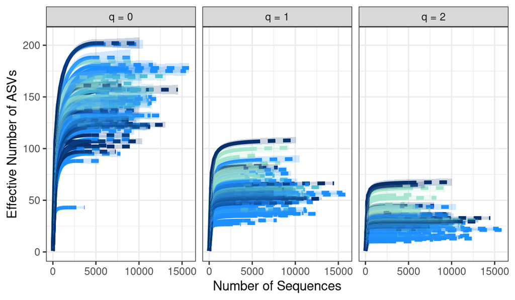

```r
ggiNEXT(iNEXT_data, type = 1, facet.var = "Order.q") +
  scale_color_manual(values = iNEXT_color_df$salinity_colors) +
  scale_fill_manual(values = iNEXT_color_df$salinity_colors) +
  theme_bw() +
  theme(legend.position = "none") +
  labs(y = "Effective Number of ASVs", x = "Number of Sequences")
```

Remembering that an Order q of:

- 0 = Richness/ Number of Total taxa
- 1 = Exponential Shannon / Number of “Common” taxa
- 2 = Inverse Simpson / Number of “Dominant” taxa

*Also note that iNEXT will extrapolate the number of sequences to double the sequencing depth of the sample!* This extrapolation is represented by the dotted line, which extends to 2 x the library size of the sample.

Ok, this plot is nice, but since it’s autogenerated with the `ggiNEXT` function, I’d like some more freedom to plot and explore the data further. Let’s manually plot the data that we pull out from the iNEXT data.

## Manual Rarefaction Curves

```r
str(iNEXT_data)
```

```
## List of 3
##  $ DataInfo:'data.frame':    89 obs. of  14 variables:
##   ..$ Assemblage: chr [1:89] "X20210602.MA.ABB1F" "X20210602.MA.ABB1P" "X20210602.MA.ABB1W" "X20210602.MA.ABS1F" ...
##   ..$ n         : num [1:89] 4079 3087 5749 3843 3767 ...
##   ..$ S.obs     : num [1:89] 141 123 150 127 140 132 140 121 147 131 ...
##   ..$ SC        : num [1:89] 1 1 1 1 1 1 1 1 1 1 ...
##   ..$ f1        : num [1:89] 0 0 0 0 0 0 0 0 0 0 ...
##   ..$ f2        : num [1:89] 4 19 13 12 10 9 8 11 10 12 ...
##   ..$ f3        : num [1:89] 12 9 10 6 11 5 5 5 9 3 ...
##   ..$ f4        : num [1:89] 7 8 8 5 9 7 5 8 5 5 ...
##   ..$ f5        : num [1:89] 7 4 7 9 3 10 6 6 7 8 ...
##   ..$ f6        : num [1:89] 7 8 5 9 8 3 7 3 7 2 ...
##   ..$ f7        : num [1:89] 2 5 6 5 9 5 3 6 5 7 ...
##   ..$ f8        : num [1:89] 3 3 2 5 7 7 2 4 5 6 ...
##   ..$ f9        : num [1:89] 8 2 5 2 6 4 5 3 4 3 ...
##   ..$ f10       : num [1:89] 7 5 9 5 1 5 7 6 10 4 ...
##  $ iNextEst:List of 2
##   ..$ size_based    :'data.frame':   10680 obs. of  10 variables:
##   .. ..$ Assemblage: chr [1:10680] "X20210602.MA.ABB1F" "X20210602.MA.ABB1F" "X20210602.MA.ABB1F" "X20210602.MA.ABB1F" ...
##   .. ..$ m         : num [1:10680] 1 227 454 680 907 ...
##   .. ..$ Method    : chr [1:10680] "Rarefaction" "Rarefaction" "Rarefaction" "Rarefaction" ...
##   .. ..$ Order.q   : num [1:10680] 0 0 0 0 0 0 0 0 0 0 ...
##   .. ..$ qD        : num [1:10680] 1 76.7 102.5 115.6 123.4 ...
##   .. ..$ qD.LCL    : num [1:10680] 1 75.4 100.7 113.5 121 ...
##   .. ..$ qD.UCL    : num [1:10680] 1 78 104 118 126 ...
##   .. ..$ SC        : num [1:10680] 0.0424 0.8347 0.9229 0.9565 0.9727 ...
##   .. ..$ SC.LCL    : num [1:10680] 0.0395 0.8301 0.9194 0.9539 0.9709 ...
##   .. ..$ SC.UCL    : num [1:10680] 0.0452 0.8393 0.9264 0.959 0.9746 ...
##   ..$ coverage_based:'data.frame':   5073 obs. of  8 variables:
##   .. ..$ Assemblage: chr [1:5073] "X20210602.MA.ABB1F" "X20210602.MA.ABB1F" "X20210602.MA.ABB1F" "X20210602.MA.ABB1F" ...
##   .. ..$ SC        : num [1:5073] 0.0424 0.8347 0.9229 0.9565 0.9727 ...
##   .. ..$ m         : num [1:5073] 1 227 454 680 907 ...
##   .. ..$ Method    : chr [1:5073] "Rarefaction" "Rarefaction" "Rarefaction" "Rarefaction" ...
##   .. ..$ Order.q   : num [1:5073] 0 0 0 0 0 0 0 0 0 0 ...
##   .. ..$ qD        : num [1:5073] 1 76.7 102.5 115.6 123.4 ...
##   .. ..$ qD.LCL    : num [1:5073] 0.963 74.645 99.883 112.721 120.416 ...
##   .. ..$ qD.UCL    : num [1:5073] 1.04 78.81 105.04 118.48 126.48 ...
##  $ AsyEst  :'data.frame':    267 obs. of  7 variables:
##   ..$ Assemblage: chr [1:267] "X20210602.MA.ABB1F" "X20210602.MA.ABB1F" "X20210602.MA.ABB1F" "X20210602.MA.ABB1P" ...
##   ..$ Diversity : chr [1:267] "Species richness" "Shannon diversity" "Simpson diversity" "Species richness" ...
##   ..$ Observed  : num [1:267] 141 56.5 23.5 123 48.2 ...
##   ..$ Estimator : num [1:267] 141 57.4 23.6 123 49.1 ...
##   ..$ s.e.      : num [1:267] 1.865 1.371 0.936 3.63 1.245 ...
##   ..$ LCL       : num [1:267] 141 54.8 21.8 123 46.7 ...
##   ..$ UCL       : num [1:267] 144.7 60.1 25.4 130.1 51.6 ...
##  - attr(*, "class")= chr "iNEXT"
```

```r
iNEXT_manual_df <-
  iNEXT_data$iNextEst$size_based %>%
  dplyr::rename(names = Assemblage) %>%
  # fix the samples to merge with metadata
  mutate(names = gsub(names, pattern = "[.]", replace = "-"),
         names = gsub(names, pattern = "X", replace = "")) %>%
  # join with the metadata
  left_join(., metadata_df, by = "names")

# Inspection
dim(iNEXT_manual_df)
```

```
## [1] 10680    52
```

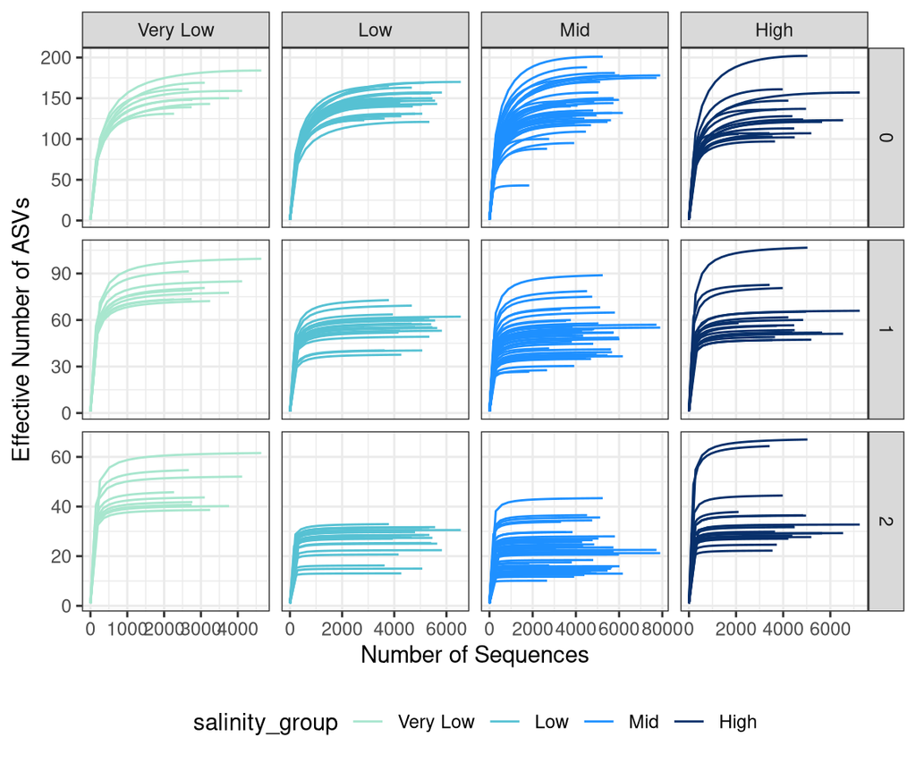

```r
# Manually plot rarefaction curves
iNEXT_manual_df %>%
  # Filter out rows that are calculated with actual sequences (no extrapolated)
  dplyr::filter(Method == "Rarefaction") %>%
  # Now, let's draw the plot!
  ggplot(aes(x = m, y = qD, color = salinity_group, group = names)) +
  geom_line() +
  # Facet by station
  facet_grid(Order.q~salinity_group, scales = "free") +
  scale_color_manual(values = salinity_colors) +
  theme_bw() +
  labs(y = "Effective Number of ASVs", x = "Number of Sequences") +
  theme(legend.position = "bottom")
```

INTERPRETATION #1: What can you conclude from the ggiNEXT and manual rarefaction curve plots? Are there “enough” sequences to analyze the samples? Is it valid to make any conclusions about species richness when q = 0? What about when q = 1? Or q = 2? Why or why not?

While the rarefaction curves from `ggiNEXT` agglomerated the data together, it was hard to see individual samples. Above, we can start to tease apart specific samples within each station, which can be done for any categorical variable.

**Some initial take-aways:**

- *Richness: q = 0*
  - All the samples with **richness plateau! This is essential and determines whether or not we can make conclusions about the observed richness!** If the richness values do not plateau, then we cannot make any assertions regarding the ASV richness in the samples because the samples have not been sequenced deeply enough to measure this. Instead, we *might* be able to rely on the extrapolated values, however, this will require a lot of caution.
  - There does not appear to be much difference between the salinity groups in the total richness.
  - However, there does appear to be a lower outlier sample in the Mid group! Again, we will keep an eye on this sample.
- *Shannon Diversity: q = 1*
  - Here, the trends that were starting to be witnessed in the Shannon diversity are more amplified.
- *Simpson’s Diversity: q = 2*
  - The **Very Low** seems to generally be the highest with 40-60 dominant species versus.
  - The **Low** and **Mid** groups appears to have the lowest Simpson’s diversity as the plateau is ~10-30 dominant taxa.
  - There are two samples in the **High** salinity group that have much larger Simpson Diversity values compared to other samples. Wonder which sample those are!

However, all of these changes are qualitative… let’s actually quantify by running some stats!

# Statististical Testing

So, how do we actually quantify the changes in biodiversity that we may observe between the samples? That takes us into statistics!

## Parametric vs. Non-Parametric Statistics??

Understanding the difference between **parametric** and **non-parametric** statistics is essential for choosing the right test for your data, especially in microbial ecology where data often violate assumptions of normality.

*So, what’s the difference between the two?*

| Feature | Parametric | Non-Parametric |
| --- | --- | --- |
| **Assumptions** | Assumes a known distribution (usually normal) | Fewer assumptions about distribution |
| **Data Type** | Continuous (interval/ratio) | Ordinal or non-normal continuous |
| **Examples** | t-test, ANOVA, linear regression | Wilcoxon, Kruskal-Wallis, Spearman |
| **Estimates Based On** | Parameters like mean and variance | Ranks or medians |
| **Sensitive to Outliers?** | Yes | Less sensitive |
| **Statistical Power** | Higher if assumptions are met | Lower but more robust to violations |

### Parametric Statistics

Parametric tests assume that the data follow a specific distribution (usually a normal/Gaussian distribution). They are more statistically powerful **if those assumptions are met**. Some examples include, comparing means with a t-test or ANOVA or modeling relationships using linear regression.

```
# Example t-test on alpha diversity between two treatment groups (Shannon index)
t.test(shannon ~ treatment, data = my_data)
```

### Non-Parametric Statistics

- Data are skewed or non-normal
- Sample sizes are small
- Outliers are present
- You’re analyzing ranks (*e.g.,* ordinal data) or medians

```
# Example Wilcoxon test on alpha diversity between two treatment groups (Shannon index)
wilcox.test(shannon ~ treatment, data = my_data)
```

## How do I test if my data is “normal”?

Typically people perform a **Shapiro-Wilk Test** on their data. The Shapiro-Wilk test is a statistical test used to check whether a sample of data comes from a normally distributed population.

The Shapiro-Wilk test calculates a **W statistic** by comparing the order statistics (sorted values) of your data with those expected from a normal distribution.

- **W ≈ 1** → data is close to normal.
- **W < 1** → increasing deviation from normality.

What hypothses does the Shapiro-Wilk Test?

- *Null hypothesis (H₀):* The data are normally distributed.
  - *p-value > 0.05*: Fail to reject H₀ and the data appears normal.
- *Alternative hypothesis (H₁):* The data are *not* normally distributed.
  - *p-value < 0.05*: We can reject the H₀, which will indicate that the data is **not normal**.

**How to run the Shapiro-Wilk test?**

*Run Shapiro-Wilk for Salinity*

```r
distinct_metadata_df <-
  metadata_df %>%
  # There are some redundant samples that are specific to the in class dataset, let's remove them
  dplyr::filter(fraction == "Whole")

# Test of the data is normal for the continuous value of salinity
shapiro.test(distinct_metadata_df$salinity_psu)
```

```
##
##  Shapiro-Wilk normality test
##
## data:  distinct_metadata_df$salinity_psu
## W = 0.92798, p-value = 0.0434
```

Ok! So, the test above has a p-value <0.05, indicating that we can reject the H₀, which will indicate that the data is **not normal**. Therefore, we need to use non-parametric statistical tests in the data.

*Is the richness data normal?*

```r
### Now what about for richness?
obs_div_df <-
  iNEXT_manual_df %>%
  dplyr::filter(Method == "Observed")

# check it
glimpse(obs_div_df)
```

```
## Rows: 267
## Columns: 52
## $ names               <chr> "20210602-MA-ABB1F", "20210602-MA-ABB1F", "2021060…
## $ m                   <dbl> 4079, 4079, 4079, 3087, 3087, 3087, 5749, 5749, 57…
## $ Method              <chr> "Observed", "Observed", "Observed", "Observed", "O…
## $ Order.q             <dbl> 0, 1, 2, 0, 1, 2, 0, 1, 2, 0, 1, 2, 0, 1, 2, 0, 1,…
## $ qD                  <dbl> 141.00000, 56.45211, 23.48200, 123.00000, 48.15183…
## $ qD.LCL              <dbl> 138.39710, 54.11506, 21.90170, 119.78310, 46.24087…
## $ qD.UCL              <dbl> 143.60290, 58.78917, 25.06230, 126.21690, 50.06279…
## $ SC                  <dbl> 1, 1, 1, 1, 1, 1, 1, 1, 1, 1, 1, 1, 1, 1, 1, 1, 1,…
## $ SC.LCL              <dbl> 0.9991934, 0.9991934, 0.9991934, 0.9985814, 0.9985…
## $ SC.UCL              <dbl> 1, 1, 1, 1, 1, 1, 1, 1, 1, 1, 1, 1, 1, 1, 1, 1, 1,…
## $ year                <chr> "2021", "2021", "2021", "2021", "2021", "2021", "2…
## $ day                 <chr> "02", "02", "02", "02", "02", "02", "02", "02", "0…
## $ project             <chr> "MA", "MA", "MA", "MA", "MA", "MA", "MA", "MA", "M…
```

[output cut: 39 more lines]

```r
# Pull out unique data from the three fractions of samples
obs_whole_rich_df <-
  obs_div_df %>%
  dplyr::filter(fraction == "Whole") %>%
  dplyr::filter(Order.q == 0)

# Test of the data is normal for the continuous value of richness
shapiro.test(obs_whole_rich_df$qD)
```

```
##
##  Shapiro-Wilk normality test
##
## data:  obs_whole_rich_df$qD
## W = 0.97813, p-value = 0.7739
```

**YES!** The diversity data IS normal. This means that when we run these tests, we can use parametric tests that assume normality of our data. :) This makes our statistical testing a lot more robust. Therefore, we can use ANOVA!

## Statistics in Microbial Ecology

Generally speaking, we tend to use non-parametric tests in microbial ecology. It’s safer to go this way. However, if there is a test performed to show that the data is normally distributed, then we can access the robustness of parametric tests!

| **Research Question** | **Parametric Test** | **Non-Parametric Test** |
| --- | --- | --- |
| Compare alpha diversity (2 groups) | t-test | Wilcoxon rank-sum test |
| Compare alpha diversity (more than 2 groups) | ANOVA | Kruskal-Wallis test |
| Correlate diversity with environmental data | Pearson correlation | Spearman correlation |
| Test differences in beta diversity | *Not applicable* (uses distance matrices) | PERMANOVA (non-parametric) |
| Model transformed taxon abundances | Linear regression, GLM | Rank-based regression |

**Takeaways about statistics**

- **Parametric statistics** use data values directly (means, variances) and are more powerful when assumptions (*e.g.,* normality, homoscedasticity) are met.
- **Non-parametric statistics** use ranks and are more powerful when there are violations of assumptions that are made in parametric statistics, making them a safer choice for skewed, sparse, or ordinal data, which is commonplace in microbial ecology.
- In microbial ecology, non-parametric methods are commonly used due to the nature of microbiome data (*e.g.,* zero-inflated, non-normal, compositional), but **parametric tests are absolutely valid** when assumptions are met or appropriate transformations are applied.

Choose your statistical approach based on the:

- Type and distribution of your data
- Question you’re asking
- Assumptions your data can reasonably meet

# Categorical Analysis: 2 or more groups

### Salinity By Group

Here, in this example, our question regarding alpha diversity is related to station, which roughly correlates with salinity. In this case, we have a continuous variable on the y-axis and a categorical variable on the x-axis.

```r
# Calculate the kruskall-wallis stats
kw_station_salinity <-
  obs_whole_rich_df %>%
  kruskal_test(salinity_psu ~ station)

# Look at it
kw_station_salinity
```

```
## # A tibble: 1 × 6
##   .y.              n statistic    df         p method
## * <chr>        <int>     <dbl> <int>     <dbl> <chr>
## 1 salinity_psu    30      26.3     4 0.0000271 Kruskal-Wallis
```

```r
# post-hoc test with Dunn's Test
dunn_station_salinity <-
  obs_whole_rich_df %>%
  dunn_test(salinity_psu ~ salinity_group, p.adjust.method = "fdr") %>%
  add_xy_position(x = "salinity_group")

# look at the pairwise
dunn_station_salinity
```

```
## # A tibble: 6 × 13
##   .y.          group1  group2    n1    n2 statistic       p   p.adj p.adj.signif
##   <chr>        <chr>   <chr>  <int> <int>     <dbl>   <dbl>   <dbl> <chr>
## 1 salinity_psu Very L… Low        3     8     0.923 3.56e-1 3.56e-1 ns
## 2 salinity_psu Very L… Mid        3    13     2.84  4.54e-3 9.08e-3 **
## 3 salinity_psu Very L… High       3     6     4.10  4.19e-5 1.26e-4 ***
## 4 salinity_psu Low     Mid        8    13     2.65  7.94e-3 1.19e-2 *
## 5 salinity_psu Low     High       8     6     4.21  2.59e-5 1.26e-4 ***
## 6 salinity_psu Mid     High      13     6     2.19  2.88e-2 3.45e-2 *
## # ℹ 4 more variables: y.position <dbl>, groups <named list>, xmin <dbl>,
## #   xmax <dbl>
```

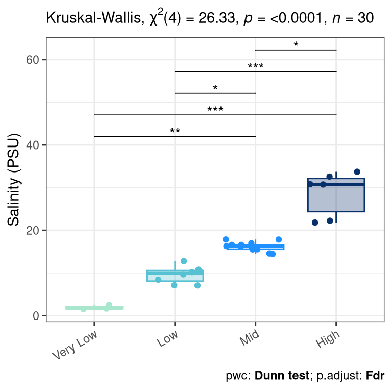

```r
# Salinity by station
salinity_ggboxplot <-
  ggboxplot(obs_whole_rich_df, x = "salinity_group", y = "salinity_psu",
          color = "salinity_group", fill = "salinity_group", alpha = 0.3,
          outlier.shape = NA) +
  # Add points
  geom_jitter(aes(color = salinity_group)) +
  scale_color_manual(values = salinity_colors) +
  scale_fill_manual(values = salinity_colors) +
  labs(y = "Salinity (PSU)") +
  # Now, let's add the KW results
  stat_pvalue_manual(dunn_station_salinity, hide.ns = TRUE,
                      tip.length = 0, step.increase = 0.01) +
  labs(subtitle = get_test_label(kw_station_salinity, detailed = TRUE),
       caption = get_pwc_label(dunn_station_salinity)) +
  theme_bw() +
  theme(legend.position = "none",
        axis.title.x = element_blank(),
        axis.text.x = element_text(angle = 30,
                                   hjust = 1,
                                   vjust = 1))

# Show the plot
salinity_ggboxplot
```

Great, this matches what we had defined during the pre-processing steps!

### Diversity by Salinity Group

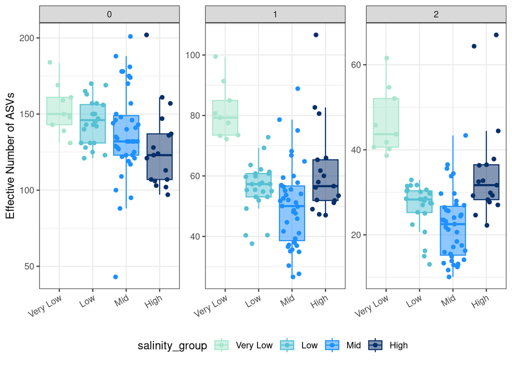

```r
# Plot boxplots by station against diversity
obs_div_df %>%
  ggplot(aes(x = salinity_group, y = qD, fill = salinity_group,
             color = salinity_group)) +
  facet_wrap(.~Order.q, scales = "free_y") +
  geom_jitter() +
  geom_boxplot(alpha = 0.5, outlier.shape = NA) +
  scale_color_manual(values = salinity_colors) +
  scale_fill_manual(values = salinity_colors) +
  labs(y = "Effective Number of ASVs") +
  theme_bw() +
  theme(legend.position = "bottom",
        axis.title.x = element_blank(),
        axis.text.x = element_text(angle = 30,
                                   hjust = 1,
                                   vjust = 1))
```

### Richness vs Salinity Group

```r
# Pull out richness data
obs_rich_df <-
  obs_div_df %>%
  dplyr::filter(Order.q == 0)

# Calculate the ANOVA since the data is normal. :)
anova_salinityGroup_rich <-
  aov(qD ~ salinity_group, data = obs_rich_df)

# Look at it
anova_salinityGroup_rich
```

```
## Call:
##    aov(formula = qD ~ salinity_group, data = obs_rich_df)
##
## Terms:
##                 salinity_group Residuals
## Sum of Squares         5140.76  52905.65
## Deg. of Freedom              3        85
##
## Residual standard error: 24.94833
## Estimated effects may be unbalanced
```

```r
summary(anova_salinityGroup_rich)
```

```
##                Df Sum Sq Mean Sq F value Pr(>F)
## salinity_group  3   5141  1713.6   2.753 0.0475 *
## Residuals      85  52906   622.4
## ---
## Signif. codes:  0 '***' 0.001 '**' 0.01 '*' 0.05 '.' 0.1 ' ' 1
```

```r
# Richness by station
rich_ggboxplot <-
  ggboxplot(obs_rich_df, x = "salinity_group", y = "qD",
          color = "salinity_group", fill = "salinity_group", alpha = 0.3,
          outlier.shape = NA) +
  # Add points
  geom_jitter(aes(color = salinity_group)) +
  scale_color_manual(values = salinity_colors) +
  scale_fill_manual(values = salinity_colors) +
  labs(y = "# of Total ASVs (Richness)") +
  # Add ANOVA & Tukey
  stat_compare_means(method = "anova", label.y = min(obs_rich_df$qD)-5) +  # ANOVA p-value
  geom_pwc(
    aes(group = salinity_group), tip.length = 0, hide.ns = TRUE,
    method = "t_test", label = "p.adj.signif",
    p.adjust.method = "fdr", bracket.nudge.y = -0.08) +
  theme_bw() +
  theme(legend.position = "none",
        axis.title.x = element_blank(),
        axis.text.x = element_text(angle = 30,
                                   hjust = 1,
                                   vjust = 1))
```

### Simpson vs Salinity Group

```r
# Pull out simpson data
obs_simps_df <-
  obs_div_df %>%
  dplyr::filter(Order.q == 2)

# Calculate the ANOVA since the data is normal. :)
anova_salinityGroup_simps <-
  aov(qD ~ salinity_group, data = obs_simps_df)

# Look at it
anova_salinityGroup_simps
```

```
## Call:
##    aov(formula = qD ~ salinity_group, data = obs_simps_df)
##
## Terms:
##                 salinity_group Residuals
## Sum of Squares        5403.862  6132.099
## Deg. of Freedom              3        85
##
## Residual standard error: 8.493665
## Estimated effects may be unbalanced
```

```r
summary(anova_salinityGroup_simps)
```

```
##                Df Sum Sq Mean Sq F value   Pr(>F)
## salinity_group  3   5404  1801.3   24.97 1.12e-11 ***
## Residuals      85   6132    72.1
## ---
## Signif. codes:  0 '***' 0.001 '**' 0.01 '*' 0.05 '.' 0.1 ' ' 1
```

```r
# Simpson by station
simps_ggboxplot <-
  ggboxplot(obs_simps_df, x = "salinity_group", y = "qD",
          color = "salinity_group", fill = "salinity_group", alpha = 0.3,
          outlier.shape = NA) +
  # Add points
  geom_jitter(aes(color = salinity_group)) +
  scale_color_manual(values = salinity_colors) +
  scale_fill_manual(values = salinity_colors) +
  labs(y = "# of Dominant ASVs (Simpson)") +
  # Add ANOVA & Tukey
  stat_compare_means(method = "anova", label.y = min(obs_simps_df$qD)-2) +  # ANOVA p-value
  geom_pwc(
    aes(group = salinity_group), tip.length = 0, hide.ns = TRUE,
    method = "t_test", label = "p.adj.signif",
    step.increase = 0.08,
    p.adjust.method = "fdr", bracket.nudge.y = -0.08) +
  theme_bw() +
  theme(legend.position = "none",
        axis.title.x = element_blank(),
        axis.text.x = element_text(angle = 30,
                                   hjust = 1,
                                   vjust = 1))
```

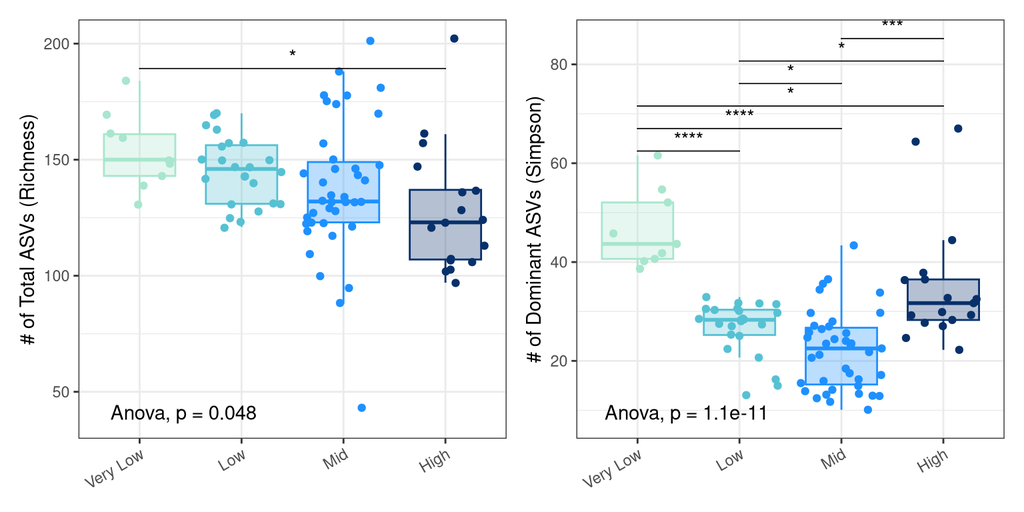

```r
# Show the plots
rich_ggboxplot + simps_ggboxplot
```

On the left, we can see that *only* the richness of the lowest and highest salinity groups are significantly different. However, on the right when evaluating Simpson’s Index (dominant ASVs), we can see that there is quite a bit of a differences between salinity groups and that there is more of a “U-shaped” differences than a general trend down on the left.

INTERPRETATION #2: If you have categorical data, what can you conclude regarding the role that all ASVs (richess, q = 0) versus common ASVs (Shannon, q = 1) versus dominant ASVs (Simpson, q = 2) have on the biodiversity of your samples as it relates to your variable of interest?

INTERPRETATION #3: How did you statistically test your scientific question in Interpretation #2? Why?

# Continuous Relationships

Here, we will test the continuous variable salinity (PSU) versus Biodiversity measures

## Spearman vs. Linear Model: What’s the Difference?

| Feature | **Spearman Correlation** | **Linear Model (`lm()`)** |
| --- | --- | --- |
| **Type of Relationship** | Monotonic (increasing or decreasing) | Linear (straight-line relationship) |
| **Assumptions** | Non-parametric (no distribution assumptions) | Parametric (normality, linearity, homoscedasticity) |
| **Input Data** | Ordinal, ranked, or continuous | Continuous (can include categorical predictors too) |
| **What it Measures** | Strength and direction of monotonic relationship | Effect size, direction, significance of predictors |
| **Output** | Correlation coefficient (ρ) and p-value | Intercept, slope(s), p-values, R², residuals, etc. |
| **Resistant to Outliers?** | More robust | Sensitive to outliers |
| **Function in R** | `cor.test(x, y, method = "spearman")` | `lm(y ~ x)` |

## Environmental Variables

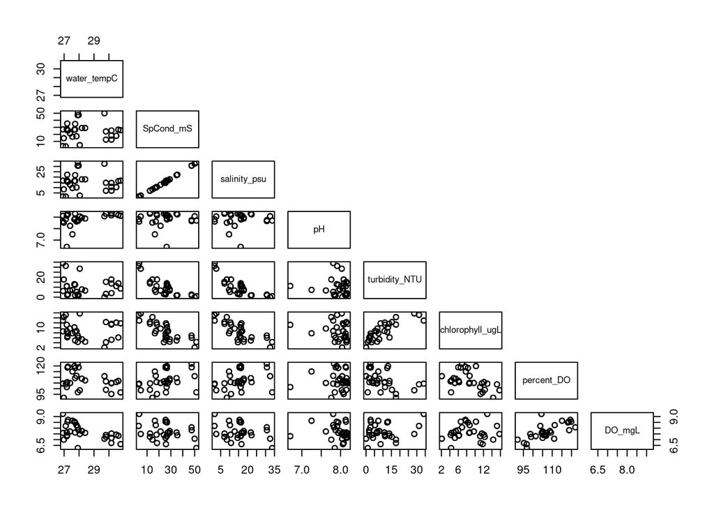

```r
# Create dataframe of environmental variables
env_df <-
  metadata_df %>%
  dplyr::select(names, water_tempC:DO_mgL)

# Pair-wise interactions between env var
pairs(dplyr::select(env_df, -names), upper.panel = NULL)
```

**IMPORTANT NOTES:**

1. This s where you can clearly see some variables are correlated! For example, `salinity_psu` and `SpCond_mS` are perfectly correlated. Therefore, we should be careful to compare these two!
2. `percent_DO` and `DO_mgL` are two measurements of dissolved oxygen arand are also correlated.
3. Finally, `turbidity_NTU` and `chlorophyll_ugL` also appear correlated and we should be mindful of these!

## Continuous Variable—Practical Salinity Units: PSU

A **Practical Salinity Unit** is equal to:

- 1 PSU = 1 g salt per 1,000 g water = 1 ppt

PSU ranges between 0 and >30, where:

- Freshwater: 0-0.5
- Brackish: 0.5 - 30
- Marine: >30

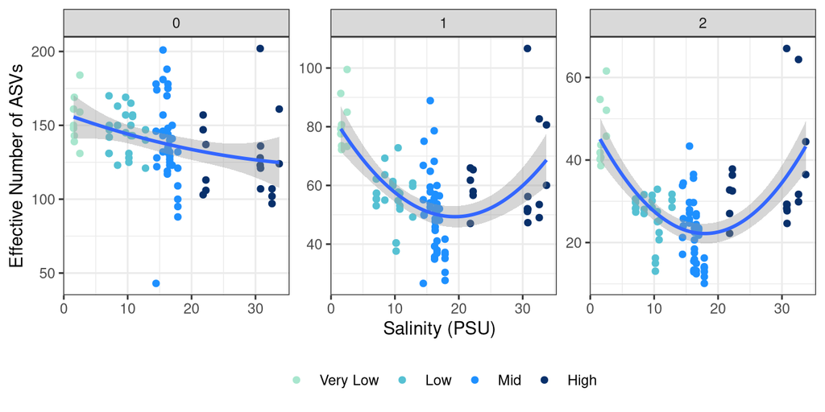

```r
# How does biodiversity change over the salinity gradient?
obs_div_df %>%
  ggplot(aes(x = salinity_psu, y = qD)) +
  facet_wrap(.~Order.q, scales = "free") +
  geom_point(aes(color = salinity_group)) +
  scale_color_manual(values = salinity_colors) +
  labs(x = "Salinity (PSU)", y = "Effective Number of ASVs") +
  stat_smooth(method = "lm", formula = y ~poly(x, 2)) +
  theme_bw() +
  theme(legend.position = "bottom",
        legend.title = element_blank())
```

Here, there appears to be a few different results:

- There appears to be a negative & linear relationship between salinity and Richness. This indicates that freshwaters have the highest number of ASVs (genearlly around ~150 ASVs) and as we gain more and more salt in the water, there are fewer species (closer to ~110 ASVs)! We will test this more below. :)
- Taking the Richness relationship above, we also need to note that there seems to be a high amount of variability within the brackish samples,
- Shannon & Simpson diversity appear to have a “U” shaped diversity curve!
- The “U” shape indicates that diversity measures that also weight relative abundance (common and dominant taxa) is highest at the two ends of the spectrum… this indicates that there are fewer dominant species in brackish waters.

### Explore Richness More

```r
# Make a richness data frame
richness_df <-
  obs_div_df %>%
  dplyr::filter(Method == "Observed") %>%
  dplyr::filter(Order.q == 0)

# Actually run the linear model
rich_vs_sal_lm <-
  lm(qD ~ salinity_psu, data = richness_df)

# Show me the model results
rich_vs_sal_lm
```

```
##
## Call:
## lm(formula = qD ~ salinity_psu, data = richness_df)
##
## Coefficients:
##  (Intercept)  salinity_psu
##     154.0382       -0.9641
```

```r
# Type?
class(rich_vs_sal_lm)
```

```
## [1] "lm"
```

```r
# Summary of lm
summary(rich_vs_sal_lm)
```

```
##
## Call:
## lm(formula = qD ~ salinity_psu, data = richness_df)
##
## Residuals:
##     Min      1Q  Median      3Q     Max
## -97.116 -15.617  -1.401  12.295  77.599
##
## Coefficients:
##              Estimate Std. Error t value Pr(>|t|)
## (Intercept)  154.0382     5.5693  27.658  < 2e-16 ***
## salinity_psu  -0.9641     0.3218  -2.996  0.00356 **
## ---
## Signif. codes:  0 '***' 0.001 '**' 0.01 '*' 0.05 '.' 0.1 ' ' 1
##
## Residual standard error: 24.59 on 87 degrees of freedom
## Multiple R-squared:  0.09354,    Adjusted R-squared:  0.08312
## F-statistic: 8.977 on 1 and 87 DF,  p-value: 0.003561
```

In the output:

- **Coefficients** refer to the 𝛽’s
- **Estimate** is the estimate of each coefficient
- **Std. Error** is the standard error of the estimate
- **t value** is the coefficient divided by its standard error
- **Pr(>|t|)** is the p-value for the coefficient
- The **residual standard error** is the estimate of the variance of 𝜖
- **Degrees of freedom** is the sample size minus # of coefficients estimated
- **R-squared** is (roughly) the proportion of variance in the outcome explained by the model, instead we should always report the **adjusted R-squared**, which takes into penalizes the addition of unnecessary predictors, which provides a more accurate measure of model fit.
  - Note that the R-squared value will always increase/stay the same when you add more predictors, even if they are not relevant!
- The **F-statistic** compares the fit of the model as a whole to the null model (with no covariates)
  - When comparing models, we always want to take the model with the higher F-statistic because it indicates a stronger relationship between the predictor varaibles and the dependent variables, suggesting that the model is better.

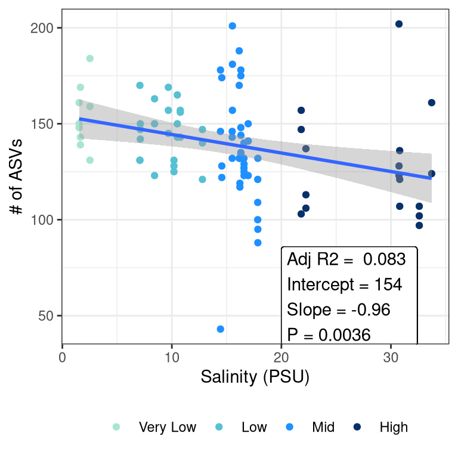

```r
richness_df %>%
  ggplot(aes(x = salinity_psu, y = qD)) +
  geom_point(aes(color = salinity_group)) +
  stat_smooth(method = "lm") +
  labs(x = "Salinity (PSU)", y = "# of ASVs") +
  scale_color_manual(values = salinity_colors) +
  theme_bw() +
  theme(legend.position = "bottom",
        legend.title = element_blank()) +
  geom_label(aes(x = 20, y = 60), hjust = 0,
             label = paste("Adj R2 = ",signif(summary(rich_vs_sal_lm)$adj.r.squared, 2),
                           "\nIntercept =",signif(rich_vs_sal_lm$coef[[1]],3),
                           " \nSlope =",signif(rich_vs_sal_lm$coef[[2]], 2),
                           " \nP =",signif(summary(rich_vs_sal_lm)$coef[2,4], 2)))
```

## Spearman Correlation

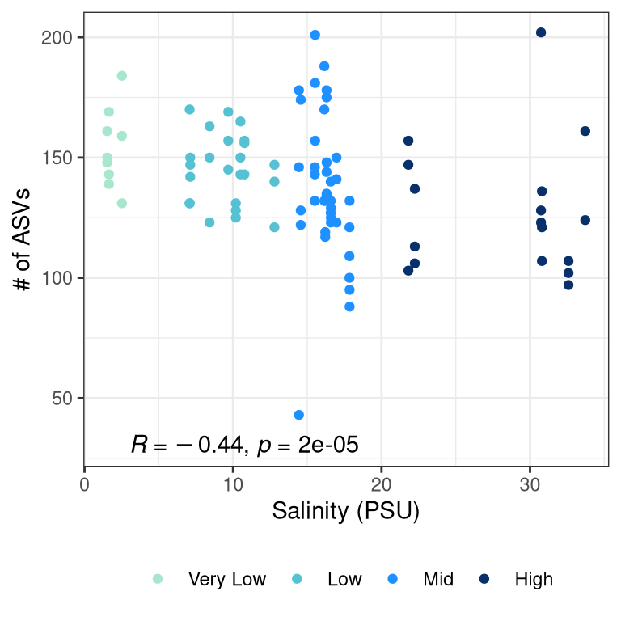

```r
richness_df %>%
  ggplot(aes(x = salinity_psu, y = qD)) +
  geom_point(aes(color = salinity_group)) +
  labs(x = "Salinity (PSU)", y = "# of ASVs") +
  scale_color_manual(values = salinity_colors) +
  theme_bw() +
  theme(legend.position = "bottom",
        legend.title = element_blank()) +
  stat_cor(method = "spearman", label.x = 3, label.y = 30)  # customize label position
```

INTERPRETATION #4: If you have continuous data, what can you conclude regarding the role that all ASVs (richess, q = 0) versus common ASVs (Shannon, q = 1) versus dominant ASVs (Simpson, q = 2) have on the biodiversity of your samples as it relates to your variable of interest?

INTERPRETATION #5: How did you statistically test your scientific question in Interpretation #4? Why?

# Final info for Reproducibility

## Check Render Time

```r
# Take the time now that we are at the end of the script
end_time <- Sys.time()
end_time
```

```
## [1] "2026-04-13 18:58:29 EDT"
```

```r
# Echo the elapsed time
elapsed_time <- round((end_time - start_time), 3)
elapsed_time
```

```
## Time difference of 12.189 secs
```